# Practical Machine Learning Course Project

Naveen Agarwal

22 November 2015

#### Executive Summary

This project is done as part of the requirement in the Practical Machine Learning course in the Data Science Specialization on Coursera.

The data for this project come from this source: http://groupware.les.inf.puc-rio.br/har.

In this project, our goal is to use data from accelerometers on the belt, forearm, arm, and dumbell of 6 participants. They were asked to perform barbell lifts correctly and incorrectly in 5 different ways. Using machine learning techniques we will predict the manner in which the participants did the exercise.

The randomForest algorithm gives 0% in-sample error and an expected 2.447% out-sample error rate.

In this report, I’ll illustrate how I built the model, used cross-validation, and why I made the choices that I did.

#### Loading data into the R environment

Assuming you have downloaded the Train and Test files into your working directory

```r
wd <- getwd()
QTrain <- read.csv(paste(wd, "Qtrain.csv", sep = "/"), stringsAsFactors = F)
QTest <- read.csv(paste(wd, "Qtest.csv", sep = "/"), stringsAsFactors = F)
## Look at the dimensions of the data.
dim(QTrain)
```

```
## [1] 19622   160
```

```r
dim(QTest)
```

```
## [1]  20 160
```

#### Remove insignificant variables

```r
x <- lapply(QTrain, function(x) sum(x == "" | is.na(x)))
y <- lapply(QTest, function(x) sum(x == "" | is.na(x)))
## Let's look at the percentage of missing values in each variable
sapply(x,FUN = function(x) round((x/19622)*100,2))
```

```
##                        X                user_name     raw_timestamp_part_1
##                     0.00                     0.00                     0.00
##     raw_timestamp_part_2           cvtd_timestamp               new_window
##                     0.00                     0.00                     0.00
##               num_window                roll_belt               pitch_belt
##                     0.00                     0.00                     0.00
##                 yaw_belt         total_accel_belt       kurtosis_roll_belt
##                     0.00                     0.00                    97.93
##      kurtosis_picth_belt        kurtosis_yaw_belt       skewness_roll_belt
##                    97.93                    97.93                    97.93
##     skewness_roll_belt.1        skewness_yaw_belt            max_roll_belt
##                    97.93                    97.93                    97.93
##           max_picth_belt             max_yaw_belt            min_roll_belt
##                    97.93                    97.93                    97.93
##           min_pitch_belt             min_yaw_belt      amplitude_roll_belt
##                    97.93                    97.93                    97.93
##     amplitude_pitch_belt       amplitude_yaw_belt     var_total_accel_belt
##                    97.93                    97.93                    97.93
##            avg_roll_belt         stddev_roll_belt            var_roll_belt
##                    97.93                    97.93                    97.93
##           avg_pitch_belt        stddev_pitch_belt           var_pitch_belt
##                    97.93                    97.93                    97.93
##             avg_yaw_belt          stddev_yaw_belt             var_yaw_belt
##                    97.93                    97.93                    97.93
##             gyros_belt_x             gyros_belt_y             gyros_belt_z
##                     0.00                     0.00                     0.00
##             accel_belt_x             accel_belt_y             accel_belt_z
##                     0.00                     0.00                     0.00
##            magnet_belt_x            magnet_belt_y            magnet_belt_z
##                     0.00                     0.00                     0.00
##                 roll_arm                pitch_arm                  yaw_arm
##                     0.00                     0.00                     0.00
##          total_accel_arm            var_accel_arm             avg_roll_arm
##                     0.00                    97.93                    97.93
##          stddev_roll_arm             var_roll_arm            avg_pitch_arm
##                    97.93                    97.93                    97.93
##         stddev_pitch_arm            var_pitch_arm              avg_yaw_arm
##                    97.93                    97.93                    97.93
##           stddev_yaw_arm              var_yaw_arm              gyros_arm_x
##                    97.93                    97.93                     0.00
```

[output cut: 53 more lines]

```
##                    97.93                     0.00                    97.93
##         avg_roll_forearm      stddev_roll_forearm         var_roll_forearm
##                    97.93                    97.93                    97.93
##        avg_pitch_forearm     stddev_pitch_forearm        var_pitch_forearm
##                    97.93                    97.93                    97.93
##          avg_yaw_forearm       stddev_yaw_forearm          var_yaw_forearm
##                    97.93                    97.93                    97.93
##          gyros_forearm_x          gyros_forearm_y          gyros_forearm_z
##                     0.00                     0.00                     0.00
##          accel_forearm_x          accel_forearm_y          accel_forearm_z
##                     0.00                     0.00                     0.00
##         magnet_forearm_x         magnet_forearm_y         magnet_forearm_z
##                     0.00                     0.00                     0.00
##                   classe
##                     0.00
```

```r
## Let's remove all variables with missing values
Train <- QTrain[,names(x[x == 0])]
Test <- QTest[,names(y[y==0])]
```

The first seven variables are either cateogrical or datetime variable.

```r
## Some exploratory analysis
table(Train$user_name, Train$classe)
```

```
##
##               A    B    C    D    E
##   adelmo   1165  776  750  515  686
##   carlitos  834  690  493  486  609
##   charles   899  745  539  642  711
##   eurico    865  592  489  582  542
##   jeremy   1177  489  652  522  562
##   pedro     640  505  499  469  497
```

```r
table(Train$new_window, Train$classe)
```

```
##
##          A    B    C    D    E
##   no  5471 3718 3352 3147 3528
##   yes  109   79   70   69   79
```

```r
table(Test$user_name); table(Test$new_window);
```

```
##
##   adelmo carlitos  charles   eurico   jeremy    pedro
##        1        3        1        4        8        3
```

```
##
## no
## 20
```

```r
## Looks like only user_name will be meaningful in predicting the classe variable.
## There is only one factor for new_window variable in the test set.
## The variable num_window will create too many factors to handle.
```

Retain user_name variable and exclude all of the first seven variables

```r
NTrain <- Train[,c(2,8:60)]
NTrain$user_name <- factor(NTrain$user_name)
NTest <- Test[,c(2,8:60)]
NTest$user_name <- factor(NTest$user_name)
```

#### Data Splitting

Split NTrain into train set and test set with 80% for training and 20% for testing

```r
library(caret)
set.seed(123)
tInd <- createDataPartition(NTrain$classe, p = .8, list = FALSE)
tTrain <- NTrain[tInd,]
tTest <- NTrain[-tInd,]
```

#### Preprocessing

Preprocess with PCA for statical significance and data compression objectives.

```r
preObj <- preProcess(tTrain[,-54], method = "pca")
tTrainPC <- predict(preObj, tTrain[,-54])
## Use same Preprocessing on the test sets.
tTestPC <- predict(preObj, tTest[,-54])
NTestPC <- predict(preObj,NTest[,-54])
dim(tTrainPC) ## Number of components.
```

```
## [1] 15699    26
```

#### Supervised learning with in built cross validation

Use random forest algorithm with 10-fold cross validation to train the tTrain dataset with the principal components in the tTrainPC dataset.

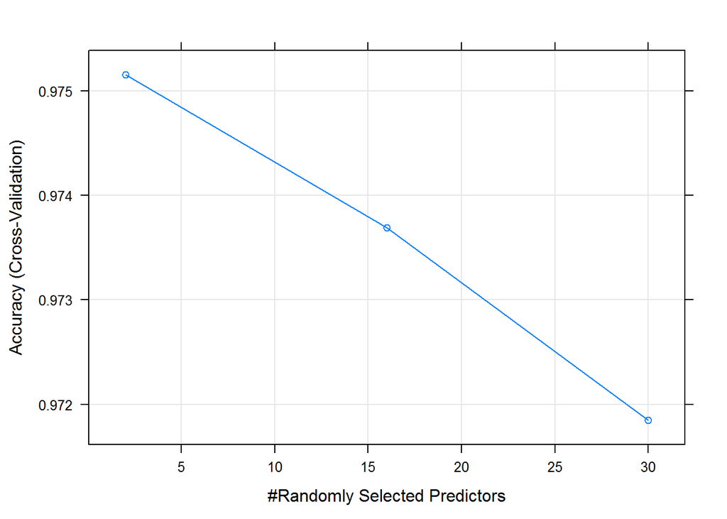

```r
rfFit <- train(tTrain$classe ~ ., tTrainPC, method = "rf", trControl = trainControl(method = "cv", number = 10))
## Let's look at the final model parameters.
plot(rfFit)
```

```r
rfFit$finalModel
```

```
##
## Call:
##  randomForest(x = x, y = y, mtry = param$mtry)
##                Type of random forest: classification
##                      Number of trees: 500
## No. of variables tried at each split: 2
##
##         OOB estimate of  error rate: 2.35%
## Confusion matrix:
##      A    B    C    D    E class.error
## A 4426    9   18    6    5 0.008512545
## B   46 2937   49    0    6 0.033245556
## C    3   33 2681   18    3 0.020818115
## D    1    2  105 2458    7 0.044694909
## E    1   12   23   22 2828 0.020097020
```

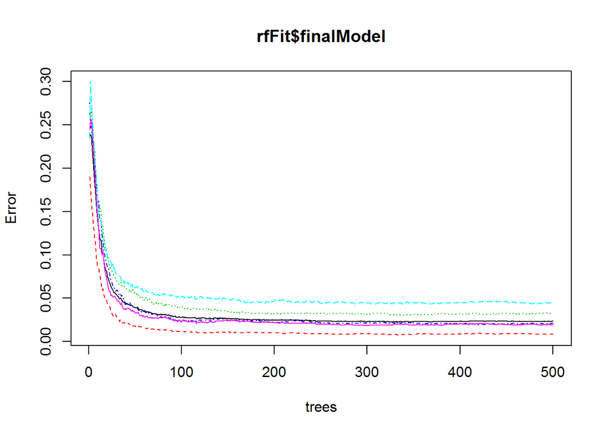

```r
plot(rfFit$finalModel)
```

#### Check in-sample and out-of-sample error rates.

```r
confusionMatrix(tTrain$classe, predict(rfFit, tTrainPC, type = "raw"))
```

```
## Confusion Matrix and Statistics
##
##           Reference
## Prediction    A    B    C    D    E
##          A 4464    0    0    0    0
##          B    0 3038    0    0    0
##          C    0    0 2738    0    0
##          D    0    0    0 2573    0
##          E    0    0    0    0 2886
##
## Overall Statistics
##
##                Accuracy : 1
##                  95% CI : (0.9998, 1)
##     No Information Rate : 0.2843
##     P-Value [Acc > NIR] : < 2.2e-16
##
##                   Kappa : 1
##  Mcnemar's Test P-Value : NA
##
## Statistics by Class:
##
##                      Class: A Class: B Class: C Class: D Class: E
## Sensitivity            1.0000   1.0000   1.0000   1.0000   1.0000
## Specificity            1.0000   1.0000   1.0000   1.0000   1.0000
## Pos Pred Value         1.0000   1.0000   1.0000   1.0000   1.0000
## Neg Pred Value         1.0000   1.0000   1.0000   1.0000   1.0000
## Prevalence             0.2843   0.1935   0.1744   0.1639   0.1838
## Detection Rate         0.2843   0.1935   0.1744   0.1639   0.1838
## Detection Prevalence   0.2843   0.1935   0.1744   0.1639   0.1838
## Balanced Accuracy      1.0000   1.0000   1.0000   1.0000   1.0000
```

```r
confusionMatrix(tTest$classe, predict(rfFit, tTestPC, type = "raw"))
```

```
## Confusion Matrix and Statistics
##
##           Reference
## Prediction    A    B    C    D    E
##          A 1109    0    3    4    0
##          B   14  731   14    0    0
##          C    1    7  669    6    1
##          D    2    0   33  606    2
##          E    0    3    5    2  711
##
## Overall Statistics
##
##                Accuracy : 0.9753
##                  95% CI : (0.9699, 0.9799)
##     No Information Rate : 0.287
##     P-Value [Acc > NIR] : < 2.2e-16
##
##                   Kappa : 0.9687
##  Mcnemar's Test P-Value : NA
##
## Statistics by Class:
##
##                      Class: A Class: B Class: C Class: D Class: E
## Sensitivity            0.9849   0.9865   0.9240   0.9806   0.9958
## Specificity            0.9975   0.9912   0.9953   0.9888   0.9969
## Pos Pred Value         0.9937   0.9631   0.9781   0.9425   0.9861
## Neg Pred Value         0.9939   0.9968   0.9830   0.9963   0.9991
## Prevalence             0.2870   0.1889   0.1846   0.1575   0.1820
## Detection Rate         0.2827   0.1863   0.1705   0.1545   0.1812
## Detection Prevalence   0.2845   0.1935   0.1744   0.1639   0.1838
## Balanced Accuracy      0.9912   0.9889   0.9597   0.9847   0.9963
```

```r
## In-sample error rate
1 - confusionMatrix(tTrain$classe, predict(rfFit, tTrainPC, type = "raw"))$overall[1]
```

```
## Accuracy
##        0
```

```r
## Expected out-of-sample error rate.
1 - confusionMatrix(tTest$classe, predict(rfFit, tTestPC, type = "raw"))$overall[1]
```

```
##   Accuracy
## 0.02447107
```

#### Predicting Test Cases

```r
## Use the random forest model to predict classe for each of the 20 cases in the test set.
predict(rfFit, NTestPC, type = "raw")
```

```
##  [1] B A A A A E D B A A B C B A E E A B B B
## Levels: A B C D E
```